# TODO: Title

## Model Profiling and Debugging

TODO: Using the best hyperparameters, create and finetune a new model

**Note:** You will need to use the `train_model.py` script to perform model profiling and debugging.

```python
# TODO: Set up debugging and profiling rules and hooks
from sagemaker.debugger import(
Rule,
rule_configs,
ProfilerRule,
DebuggerHookConfig,
# CollectionConfig,
ProfilerConfig,
FrameworkProfile)

rules=[
    Rule.sagemaker(rule_configs.vanishing_gradient()),
    Rule.sagemaker(rule_configs.overfit()),
    Rule.sagemaker(rule_configs.overtraining()),
    Rule.sagemaker(rule_configs.poor_weight_initialization()),
    ProfilerRule.sagemaker(rule_configs.ProfilerReport()),
]


profiler_config=ProfilerConfig(
system_monitor_interval_millis=500,framework_profile_params=FrameworkProfile(num_steps=10))
debugger_config = DebuggerHookConfig(
    hook_parameters={"train.save_interval": "100", "eval.save_interval": "10"}
)
```

```python
# TODO: Create and fit an estimator

estimator = PyTorch(
    entry_point = "train_model.py",
    instance_count = 1,
    instance_type = "ml.g4dn.xlarge",
    hyperparameters = best_hyperparameters,
    framework_version = "1.6",
    py_version = "py36",
    role = role,
    profiler_config = profiler_config,
    debugger_hook_config = debugger_config
)# TODO: Your estimator here
estimator.fit({'train' : input_data },wait=True)
```

[output not shown]

[output cut: 132 more lines]

```
INFO:__main__:Epoch 2 - Starting Training phase.
INFO:__main__:Epoch: 2 - Training Model on Complete Training Dataset!
INFO:__main__:
Train set: Average loss: 1.3454, Accuracy: 4579/6680 (69%)
INFO:__main__:Epoch 2 - Starting Testing phase.
INFO:__main__:Epoch: 2 - Testing Model on Complete Testing Dataset!
INFO:__main__:
Test set: Average loss: 1.1853, Accuracy: 588/836 (70%)
INFO:__main__:Starting to Save the Model
INFO:__main__:Completed Saving the Model

2022-02-21 02:44:07 Uploading - Uploading generated training model
2022-02-21 02:44:27 Completed - Training job completed
Training seconds: 540
Billable seconds: 540
```

```python
job_name = estimator.latest_training_job.name
client = estimator.sagemaker_session.sagemaker_client
description = client.describe_training_job(TrainingJobName=estimator.latest_training_job.name)

print(f"Job name:{job_name}")
print(f"client:{client}")
```

```
Job name:pytorch-training-2022-02-21-02-34-00-441
client:<botocore.client.SageMaker object at 0x7f38f15eaf50>
```

```python
print(f"description:{description}")
```

```
description:{'TrainingJobName': 'pytorch-training-2022-02-21-02-34-00-441', 'TrainingJobArn': 'arn:aws:sagemaker:us-east-1:513508352252:training-job/pytorch-training-2022-02-21-02-34-00-441', 'ModelArtifacts': {'S3ModelArtifacts': 's3://sagemaker-us-east-1-513508352252/pytorch-training-2022-02-21-02…
```

```python
from smdebug.trials import create_trial
from smdebug.core.modes import ModeKeys
trial = create_trial(estimator.latest_job_debugger_artifacts_path())
```

```
[2022-02-21 02:56:32.136 datascience-1-0-ml-g4dn-xlarge-94fad2f4401e538ca1255dfa1e84:19 INFO utils.py:27] RULE_JOB_STOP_SIGNAL_FILENAME: None
[2022-02-21 02:56:32.151 datascience-1-0-ml-g4dn-xlarge-94fad2f4401e538ca1255dfa1e84:19 INFO s3_trial.py:42] Loading trial debug-output at path s3://sagemaker-us-east-1-513508352252/pytorch-training-2022-02-21-02-34-00-441/debug-output
```

```python
trial.tensor_names()
```

```
[2022-02-21 02:56:57.985 datascience-1-0-ml-g4dn-xlarge-94fad2f4401e538ca1255dfa1e84:19 INFO trial.py:198] Training has ended, will refresh one final time in 1 sec.
[2022-02-21 02:56:59.004 datascience-1-0-ml-g4dn-xlarge-94fad2f4401e538ca1255dfa1e84:19 INFO trial.py:210] Loaded all steps
```

```
['CrossEntropyLoss_output_0']
```

```python
len(trial.tensor("CrossEntropyLoss_output_0").steps(mode=ModeKeys.TRAIN))
```

```
2
```

```python
len(trial.tensor("CrossEntropyLoss_output_0").steps(mode=ModeKeys.EVAL))
```

```
2
```

```python
# TODO: Plot a debugging output.
import matplotlib.pyplot as plt
from mpl_toolkits.axes_grid1 import host_subplot

#utility function to get data from tensors
def get_data(trial, tname, mode):
    tensor = trial.tensor(tname)
    steps = tensor.steps(mode=mode)
    vals = []
    for s in steps:
        vals.append(tensor.value(s, mode=mode))
    return steps, vals

#plot tensor utility functions for plotting tensors
def plot_tensor(trial, tensor_name):

    steps_train, vals_train = get_data(trial, tensor_name, mode=ModeKeys.TRAIN)
    print("loaded TRAIN data")
    steps_eval, vals_eval = get_data(trial, tensor_name, mode=ModeKeys.EVAL)
    print("loaded EVAL data")

    fig = plt.figure(figsize=(10, 7))
    host = host_subplot(111)

    par = host.twiny()

    host.set_xlabel("Steps (TRAIN)")
    par.set_xlabel("Steps (EVAL)")
    host.set_ylabel(tensor_name)

    (p1,) = host.plot(steps_train, vals_train, label=tensor_name)
    print("Completed TRAIN plot")
    (p2,) = par.plot(steps_eval, vals_eval, label="val_" + tensor_name)
    print("Completed EVAL plot")
    leg = plt.legend()

    host.xaxis.get_label().set_color(p1.get_color())
    leg.texts[0].set_color(p1.get_color())

    par.xaxis.get_label().set_color(p2.get_color())
    leg.texts[1].set_color(p2.get_color())

    plt.ylabel(tensor_name)
    plt.show()
```

```
loaded TRAIN data
loaded EVAL data
Completed TRAIN plot
Completed EVAL plot
```

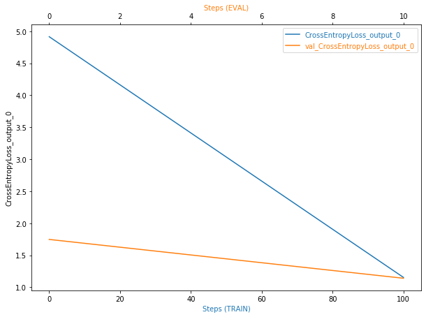

```python
plot_tensor(trial, "CrossEntropyLoss_output_0")
```

**TODO**: Is there some anomalous behaviour in your debugging output? If so, what is the error and how will you fix it?  
The output is not as smooth as expected. Adding the layers to the pre-trained model can help make it smooth. **TODO**: If not, suppose there was an error. What would that error look like and how would you have fixed it? Making some adjustments in the pretrained model to use a different set of the fully connected layers network.

```python
# TODO: Display the profiler output
rule_output_path = estimator.output_path + estimator.latest_training_job.job_name + "/rule-output"
print(f"Profiler report location: {rule_output_path}")
```

```
Profiler report location: s3://sagemaker-us-east-1-513508352252/pytorch-training-2022-02-21-02-34-00-441/rule-output
```

```python
! aws s3 ls {rule_output_path} --recursive
```

```
2022-02-21 02:44:35     393987 pytorch-training-2022-02-21-02-34-00-441/rule-output/ProfilerReport-1645410840/profiler-output/profiler-report.html
2022-02-21 02:44:35     245433 pytorch-training-2022-02-21-02-34-00-441/rule-output/ProfilerReport-1645410840/profiler-output/profiler-report.ipynb
2022-02-21 02:44:29        192 pytorch-training-2022-02-21-02-34-00-441/rule-output/ProfilerReport-1645410840/profiler-output/profiler-reports/BatchSize.json
2022-02-21 02:44:29      16101 pytorch-training-2022-02-21-02-34-00-441/rule-output/ProfilerReport-1645410840/profiler-output/profiler-reports/CPUBottleneck.json
2022-02-21 02:44:30        126 pytorch-training-2022-02-21-02-34-00-441/rule-output/ProfilerReport-1645410840/profiler-output/profiler-reports/Dataloader.json
2022-02-21 02:44:29        130 pytorch-training-2022-02-21-02-34-00-441/rule-output/ProfilerReport-1645410840/profiler-output/profiler-reports/GPUMemoryIncrease.json
2022-02-21 02:44:29       2851 pytorch-training-2022-02-21-02-34-00-441/rule-output/ProfilerReport-1645410840/profiler-output/profiler-reports/IOBottleneck.json
2022-02-21 02:44:29        308 pytorch-training-2022-02-21-02-34-00-441/rule-output/ProfilerReport-1645410840/profiler-output/profiler-reports/LoadBalancing.json
2022-02-21 02:44:29        348 pytorch-training-2022-02-21-02-34-00-441/rule-output/ProfilerReport-1645410840/profiler-output/profiler-reports/LowGPUUtilization.json
2022-02-21 02:44:29        232 pytorch-training-2022-02-21-02-34-00-441/rule-output/ProfilerReport-1645410840/profiler-output/profiler-reports/MaxInitializationTime.json
2022-02-21 02:44:29       1456 pytorch-training-2022-02-21-02-34-00-441/rule-output/ProfilerReport-1645410840/profiler-output/profiler-reports/OverallFrameworkMetrics.json
2022-02-21 02:44:29        625 pytorch-training-2022-02-21-02-34-00-441/rule-output/ProfilerReport-1645410840/profiler-output/profiler-reports/OverallSystemUsage.json
2022-02-21 02:44:29       2206 pytorch-training-2022-02-21-02-34-00-441/rule-output/ProfilerReport-1645410840/profiler-output/profiler-reports/StepOutlier.json
```

```python
! aws s3 cp {rule_output_path} ./ --recursive
```

[output not shown]

```python
# get the autogenerated folder name of profiler report
profiler_report_name = [
    rule["RuleConfigurationName"]
    for rule in estimator.latest_training_job.rule_job_summary()
    if "Profiler" in rule["RuleConfigurationName"]
][0]

profiler_report_name
```

```
'ProfilerReport-1645410840'
```

```python
import IPython


IPython.display.HTML(filename=profiler_report_name + "/profiler-output/profiler-report.html")
```

SageMaker Debugger Profiling Report

SageMaker Debugger auto generated this report. You can generate similar reports on all supported training jobs. The report provides summary of training job, system resource usage statistics, framework metrics, rules summary, and detailed analysis from each rule. The graphs and tables are interactive.

**Legal disclaimer:** This report and any recommendations are provided for informational purposes only and are not definitive. You are responsible for making your own independent assessment of the information.

```
# Parameters
processing_job_arn = "arn:aws:sagemaker:us-east-1:513508352252:processing-job/pytorch-training-2022-02-2-profilerreport-1645410840-4d2a2ff3"
```

Training job summary

[interactive chart not shown]

System usage statistics

[interactive chart not shown]

Framework metrics summary

[interactive chart not shown]

Overview: CPU operators

[interactive chart not shown]

Overview: GPU operators

[interactive chart not shown]

Rules summary

The following table shows a profiling summary of the Debugger built-in rules. The table is sorted by the rules that triggered the most frequently. During your training job, the LowGPUUtilization rule was the most frequently triggered. It processed 1006 datapoints and was triggered 1 times.

|  | Description | Recommendation | Number of times rule triggered | Number of datapoints | Rule parameters |
| --- | --- | --- | --- | --- | --- |
| LowGPUUtilization | Checks if the GPU utilization is low or fluctuating. This can happen due to bottlenecks, blocking calls for synchronizations, or a small batch size. | Check if there are bottlenecks, minimize blocking calls, change distributed training strategy, or increase the batch size. | 1 | 1006 | threshold_p95:70 threshold_p5:10 window:500 patience:1000 |
| GPUMemoryIncrease | Measures the average GPU memory footprint and triggers if there is a large increase. | Choose a larger instance type with more memory if footprint is close to maximum available memory. | 0 | 1006 | increase:5 patience:1000 window:10 |
| BatchSize | Checks if GPUs are underutilized because the batch size is too small. To detect this problem, the rule analyzes the average GPU memory footprint, the CPU and the GPU utilization. | The batch size is too small, and GPUs are underutilized. Consider running on a smaller instance type or increasing the batch size. | 0 | 1005 | cpu_threshold_p95:70 gpu_threshold_p95:70 gpu_memory_threshold_p95:70 patience:1000 window:500 |
| CPUBottleneck | Checks if the CPU utilization is high and the GPU utilization is low. It might indicate CPU bottlenecks, where the GPUs are waiting for data to arrive from the CPUs. The rule evaluates the CPU and GPU… | Consider increasing the number of data loaders or applying data pre-fetching. | 0 | 1030 | threshold:50 cpu_threshold:90 gpu_threshold:10 patience:1000 |
| MaxInitializationTime | Checks if the time spent on initialization exceeds a threshold percent of the total training time. The rule waits until the first step of training loop starts. The initialization can take longer if do… | Initialization takes too long. If using File mode, consider switching to Pipe mode in case you are using TensorFlow framework. | 0 | 120 | threshold:20 |
| IOBottleneck | Checks if the data I/O wait time is high and the GPU utilization is low. It might indicate IO bottlenecks where GPU is waiting for data to arrive from storage. The rule evaluates the I/O and GPU utili… | Pre-fetch data or choose different file formats, such as binary formats that improve I/O performance. | 0 | 1030 | threshold:50 io_threshold:50 gpu_threshold:10 patience:1000 |
| LoadBalancing | Detects workload balancing issues across GPUs. Workload imbalance can occur in training jobs with data parallelism. The gradients are accumulated on a primary GPU, and this GPU might be overused with … | Choose a different distributed training strategy or a different distributed training framework. | 0 | 1006 | threshold:0.2 patience:1000 |
| Dataloader | Checks how many data loaders are running in parallel and whether the total number is equal the number of available CPU cores. The rule triggers if number is much smaller or larger than the number of a… | Change the number of data loader processes. | 0 | 0 | min_threshold:70 max_threshold:200 |
| StepOutlier | Detects outliers in step duration. The step duration for forward and backward pass should be roughly the same throughout the training. If there are significant outliers, it may indicate a system stall… | Check if there are any bottlenecks (CPU, I/O) correlated to the step outliers. | 0 | 120 | threshold:3 mode:None n_outliers:10 stddev:3 |

Analyzing the training loop

Step duration analysis

[interactive chart not shown]

**Step durations on node algo-1-26:**

The following table is a summary of the statistics of step durations measured on node algo-1-26. The rule has analyzed the step duration from Step:ModeKeys.TRAIN phase. The average step duration on node algo-1-26 was 0.45s. The rule detected 7 outliers, where step duration was larger than 3 times the standard deviation of 1.27s

|  | mean | max | p99 | p95 | p50 | min |
| --- | --- | --- | --- | --- | --- | --- |
| Step Durations in [s] | 0.45 | 4.59 | 4.57 | 4.53 | 0.02 | 0.01 |

The following histogram shows the step durations measured on the different nodes. You can turn on or turn off the visualization of histograms by selecting or unselecting the labels in the legend.

[interactive chart not shown]

GPU utilization analysis

**Usage per GPU**

[interactive chart not shown]

**GPU utilization of gpu0 on node algo-1:**

[interactive chart not shown]

**Workload balancing**

[interactive chart not shown]

Dataloading analysis

[interactive chart not shown]

Batch size

[interactive chart not shown]

CPU bottlenecks

[interactive chart not shown]

I/O bottlenecks

[interactive chart not shown]

GPU memory

[interactive chart not shown]

[figure not shown]

## Model Deploying

```python
# TODO: Deploy your model to an endpoint

predictor=estimator.deploy(initial_instance_count=1, instance_type="ml.g4dn.xlarge") # TODO: Add your deployment configuration like instance type and number of instances
```

```
-------!
```

```python
model_data = estimator.output_path + estimator.latest_training_job.job_name + "/output/model.tar.gz"
print(f"Model: {model_data}")
```

```
Model: s3://sagemaker-us-east-1-513508352252/pytorch-training-2022-02-21-02-34-00-441/output/model.tar.gz
```

```python
test_dir = "s3://sagemaker-us-east-1-513508352252"
prefix = "dogImages/test/040.Bulldog/"
test_images = []

my_bucket = s3.Bucket(bucket)

for image in my_bucket.objects.filter(Prefix=prefix):
    test_images.append(image.key)
print(test_images)
```

```
['dogImages/test/040.Bulldog/Bulldog_02817.jpg', 'dogImages/test/040.Bulldog/Bulldog_02828.jpg', 'dogImages/test/040.Bulldog/Bulldog_02834.jpg', 'dogImages/test/040.Bulldog/Bulldog_02835.jpg', 'dogImages/test/040.Bulldog/Bulldog_02842.jpg', 'dogImages/test/040.Bulldog/Bulldog_02845.jpg', 'dogImages/…
```

[output not shown]

```python
# TODO: Run an prediction on the endpoint3.Bucket(name='sagemaker-us-ea
from sagemaker.pytorch import PyTorchModel
from sagemaker.predictor import Predictor
jpeg_serializer = sagemaker.serializers.IdentitySerializer("image/jpeg")
json_deserializer = sagemaker.deserializers.JSONDeserializer()

class ImgPredictor(Predictor):
    def __init__( self, endpoint_name, sagemaker_session):
        super( ImgPredictor, self).__init__(
            endpoint_name,
            sagemaker_session = sagemaker_session,
            serializer = jpeg_serializer,
            deserializer = json_deserializer
        )

pytorch_model = PyTorchModel( model_data = model_data,
                            role = role,
                            entry_point= "inference.py",
                            py_version = "py36",
                            framework_version = "1.6",
                             predictor_cls = ImgPredictor
                            )

predictor = pytorch_model.deploy( initial_instance_count = 1, instance_type = "ml.g4dn.xlarge")
```

```
-------!
```

```python
endpoint_name= predictor.endpoint_name
endpoint_name
```

```
'pytorch-inference-2022-02-21-03-35-33-093'
```

```python
test_dir = "./test_images"

test_images = os.listdir(test_dir)
test_images
```

```
['Bearded_collie_01274.jpg',
 'Bulldog_02845.jpg',
 'Bulldog_02846.jpg',
 'Bearded_collie_01253.jpg',
 'Bulldog_02842.jpg']
```

```
Test image no: 1
Image to be tested:
```

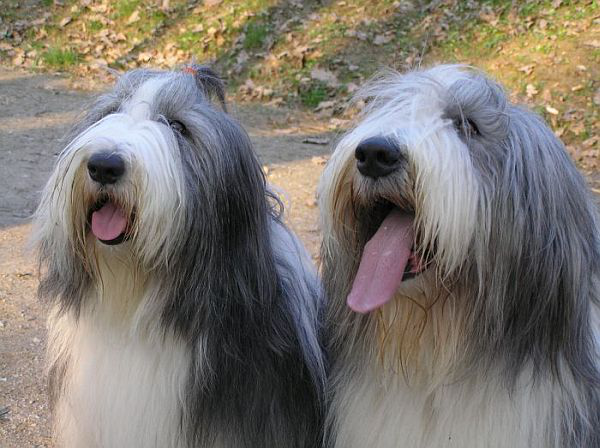

```
Response: [[-5.41949654 -2.76667929 -6.0012064  -7.08866262 -5.11583376 -6.09078836
  -7.73171806 -6.13068438 -8.89159584 -4.68788385 -7.49469566 -2.11754823
  -6.8148737  -7.86244488 -6.03742456 -9.02906704  4.87945318 -7.00398684
  -7.08696651 -7.95997524 -5.54763222 -6.76325369 -4.07661772 -6.00503922
  -5.54731131 -4.65075493 -7.97165346 -6.61622572 -3.61563778 -7.0619092
  -4.09771967 -7.52465248 -2.39103746 -8.30191231 -7.31560946 -0.71337742
  -7.56351614 -6.14260769 -3.93344569 -7.00993919 -7.65615892 -4.42551613
  -7.72238636 -4.72550249 -6.54749823 -5.82798862 -7.31247282 -9.52283764
  -5.37401152 -5.72644281 -5.43035698 -5.32137966 -5.8642292  -1.01918626
  -7.58067369 -4.17274904 -7.59805155 -5.76548147 -6.7365303  -6.48950624
  -5.56563473 -3.8925035  -6.58732414 -5.92489243 -5.88029814 -6.82618475
  -7.56946421 -5.94476557 -8.50067425 -7.1191783  -7.49734926 -8.48220158
  -2.87369323 -3.23905396 -0.69894993 -4.34905243 -5.83100796 -6.45494747
  -2.75725007 -6.42721367 -7.0949378  -0.73008114 -6.01113892 -5.57704401
  -6.66476107 -7.42919064 -7.16894007 -5.8887825  -2.7272234  -8.06254005
  -5.25632858 -5.6341939  -6.8147893  -2.69787216 -5.37337637 -6.9378233
  -6.29738188 -4.64846611 -2.66017246 -0.51403731 -5.0541687  -7.64334583
  -6.94454813 -4.29079819 -4.5521884  -2.41428375 -4.30374575 -6.44161129
  -7.71962976 -9.37050247 -5.00683784 -6.50466156  1.22299147 -2.31532359
  -5.10705853 -4.9977293  -3.91031575 -7.09061146  0.4601371  -7.28961134
  -7.36911631 -6.97646189 -6.55008173 -6.59849691 -4.78025389 -7.28865814
  -4.92772961 -6.2923336  -4.46336746 -5.80098581 -2.41844988 -8.55348587
  -4.46912956]]
Response/Inference for the above image is : [17]
Test image no: 2
Image to be tested:
```

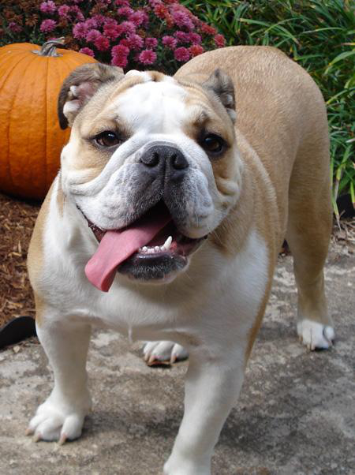

```
Response: [[ -6.93216753  -6.5779376   -6.54297543  -3.90953732  -7.29367352
   -8.97524548  -5.04594898  -0.63560838  -8.97332287  -1.63445246
   -8.28988361  -6.71692991  -8.94443512  -5.93158388  -3.40161848
   -5.54673481  -5.97616148  -9.38501167  -7.77500105  -5.97228956
  -10.35005474 -10.07775211  -7.91065359  -6.441751    -6.74013996
   -7.4160533   -6.95129871  -6.0999136   -7.9031353   -6.25468588
   -5.83133364  -2.54588437  -6.33014727  -1.25261104  -8.17149639
   -5.39480114  -5.18922901  -4.24376678  -1.38660538   3.36333871
    0.08822096  -5.84086847  -5.8236084   -1.08675063  -6.3184762
   -5.24873734  -5.2911377   -5.83817577  -6.45921135  -0.60158813
   -4.22416162  -4.9167366   -3.8015604   -7.2903347   -7.61773872
   -5.94370317  -5.19555902  -8.50597382  -8.14176655  -0.55514675
   -5.69814539  -7.13034058  -5.22063065  -5.06074762  -6.88442469
   -7.69329119  -7.79678488  -9.27811623   0.57747644  -6.60693312
   -6.36261415  -6.17490673  -7.39627981  -5.26065874  -5.8286128
   -4.06856871  -9.29065895  -3.63392472  -6.35187149  -6.18184519
   -5.33867741  -5.6978097   -5.8164835   -6.70445299  -7.17046261
   -8.78732109  -7.0454874   -5.86720657  -6.97586489  -5.3383522
   -5.85890102 -10.0493927   -6.72362566  -6.04967642  -6.60873604
   -3.45574331  -5.92659664  -6.0738101   -5.74324846  -5.28118849
   -6.90256166  -6.91947651  -1.92654169  -6.53479147  -2.97507167
   -4.25289536  -5.65599298  -5.04056549  -7.49794245  -7.59155655
   -7.51750946  -6.83657265  -7.36050987  -9.75050926  -6.85228968
   -3.34871602  -4.95735884  -7.28231668  -4.4321723   -6.02904034
   -6.19873381  -3.64600253  -8.80277252  -5.69927216  -6.84796286
   -4.28340816  -6.80268621  -3.39072919  -6.92084837  -4.28025627
   -7.04160023  -6.95084286  -6.02266645]]
Response/Inference for the above image is : [40]
Test image no: 3
Image to be tested:
```

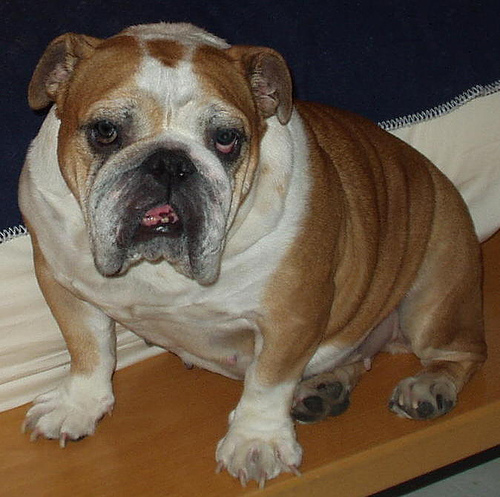

```
Response: [[-4.71107292 -6.64018536 -7.03232908 -4.16109133 -6.67650032 -6.95759535
  -4.0970397  -0.84499699 -8.52395916 -2.42075253 -7.43652487 -6.05181599
  -7.73431063 -4.92272949 -3.05060792 -5.47980118 -5.83436775 -7.89064264
  -7.60882902 -5.81321192 -9.13565063 -9.55450535 -7.16630936 -6.0848155
  -6.55194139 -6.7935195  -5.54239559 -5.79990101 -7.22015333 -5.1243763
  -6.18699694 -2.54270244 -5.58219337  0.19153771 -7.01684809 -4.91626024
  -5.35876894 -2.03209805 -1.9840194   4.39118671 -0.421736   -4.10154581
  -5.77758598 -1.95999336 -5.16475344 -5.01350355 -5.40814972 -4.31777287
  -6.26998997 -1.30245054 -3.45727181 -4.3120513  -3.65506577 -6.34693384
  -8.85385895 -4.10031414 -3.83321095 -7.82197905 -6.99807167 -0.72980052
  -5.59991026 -6.10213661 -5.90663147 -3.99275088 -6.04264688 -7.15559196
  -5.58365393 -7.96663904  1.04596961 -5.39941597 -5.84933805 -6.51766825
  -6.91961813 -3.95224929 -5.0834465  -3.4608717  -8.15855885 -3.98859072
  -5.42696381 -5.06978369 -4.95152044 -3.68578696 -5.54233313 -5.62851381
  -6.03272295 -8.03885555 -6.21750355 -7.24268198 -7.11470366 -5.29832315
  -4.6456151  -9.18106651 -5.64368105 -7.41351557 -5.52783442 -4.1719327
  -5.97837496 -6.16892481 -3.5892148  -4.10395193 -4.36905575 -6.29679394
  -1.59542608 -5.84365988 -3.24165821 -3.79543543 -4.13969231 -4.29318523
  -6.58748579 -7.25378132 -5.50223255 -6.16240263 -6.75931406 -8.96223354
  -5.70957088 -2.44862652 -3.41681266 -6.54212332 -3.6185205  -5.6685729
  -4.41673231 -3.98756838 -6.49251795 -6.74445724 -7.02076292 -3.13323951
  -5.33554888 -3.44486594 -5.77641582 -4.54328251 -7.02921581 -7.00499392
  -3.94911551]]
Response/Inference for the above image is : [40]
Test image no: 4
Image to be tested:
```

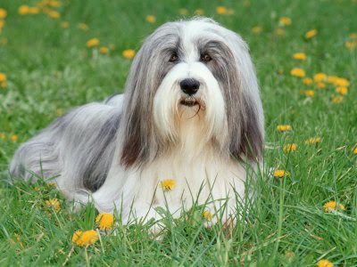

```
Response: [[-4.65663624 -2.78859568 -8.35161304 -7.68802071 -5.0661602  -6.15161371
  -7.79265308 -5.55394268 -9.07987118 -5.4869132  -7.19171    -2.45637894
  -6.38303757 -6.23784876 -5.09775305 -8.26671886  3.18303132 -8.21685314
  -7.04460049 -7.79923773 -6.85087824 -7.15400457 -5.3294611  -5.59980965
  -4.5516448  -5.45914173 -7.94689894 -4.69846773 -4.07321501 -6.15916967
  -4.96457767 -4.72682714 -4.21908712 -5.58970928 -6.4800477  -2.65774012
  -6.20098686 -3.92126465 -5.10683346 -4.86647511 -6.50747538 -3.3383522
  -8.36198902 -4.22988081 -6.77757454 -4.20402765 -7.86196852 -7.62970877
  -2.1191051  -6.0051322  -5.96710062 -5.44900846 -4.57802629 -2.24399066
  -8.27100372 -1.88618577 -5.77271414 -4.74976778 -5.54933739 -4.99199486
  -4.75814295 -2.42087841 -4.48594236 -4.07517195 -4.74673367 -6.28963947
  -7.99381685 -5.80336475 -6.10247278 -5.07432413 -7.61590481 -6.62880659
  -3.50066733 -2.94287968 -2.60962272 -4.95227432 -5.17811871 -5.48786736
  -5.85797071 -5.89374304 -5.56943274  1.34835827 -7.25427389 -4.543859
  -5.00770378 -6.58310604 -7.62359858 -5.78026772 -5.99753952 -5.68347502
  -3.44114947 -4.80162001 -5.7720933  -6.53611279 -6.81581783 -7.25390005
  -6.98921108 -5.29898787  1.20077407  1.16844285 -3.21158838 -5.78077555
  -6.26301003 -2.57487416 -4.05197906 -3.23997593 -4.09340811 -6.81757355
  -7.5892148  -8.65166187 -5.41302586 -5.9489007  -3.23998976 -4.88366318
  -2.60549402 -4.45053434 -2.72805262 -7.96378613 -0.09686577 -6.56114769
  -6.29910278 -5.33056116 -5.13009977 -6.17467499 -4.99678421 -7.37673426
  -3.80864406 -5.53639364 -5.618402   -4.49828815 -3.32840848 -7.45085621
  -2.95427418]]
Response/Inference for the above image is : [17]
Test image no: 5
Image to be tested:
```

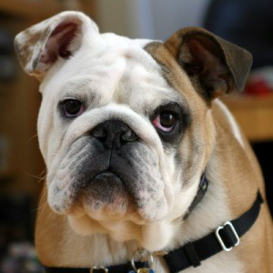

```
Response: [[-5.61137962 -5.39902639 -4.58258867 -2.9693408  -5.07622766 -6.11193895
  -3.69383383 -0.84197903 -7.21179199 -2.00577044 -5.34034681 -5.25682783
  -6.83996201 -3.33765721 -2.36188173 -4.29593372 -5.51674938 -6.0977335
  -5.87993526 -4.22898531 -7.28656483 -7.80269003 -5.94277954 -4.96108627
  -5.30556011 -6.3581543  -4.92202854 -4.79878569 -5.65920782 -4.79596281
  -4.73177052 -0.66688478 -5.67703485 -0.41165632 -6.00466824 -5.57123423
  -4.06174755 -3.16912699 -1.37159133  3.2864027  -0.8768782  -4.17722893
  -3.95782351 -1.43312216 -4.55479574 -4.22001314 -4.14841938 -3.79308391
  -5.35408163 -1.20480275 -3.06700683 -4.53954506 -3.66228914 -6.38541031
  -6.34649229 -3.89321399 -3.02575541 -6.41766453 -4.78620291 -1.27630556
  -4.08899498 -5.2497716  -4.41905785 -3.60740924 -4.53110313 -6.05571508
  -4.42373562 -6.48783445  0.81815982 -3.40366173 -4.67167854 -4.29950905
  -5.5749979  -4.10063696 -4.38413429 -3.30378389 -6.90526247 -2.62210608
  -5.09667826 -3.93726182 -2.99851084 -4.29744101 -3.98846197 -5.97561407
  -5.08432531 -6.68287849 -5.73975611 -5.64032936 -5.86053705 -2.2546711
  -4.81701899 -7.97207499 -4.27192116 -6.00041485 -5.25696468 -2.92372084
  -4.91891956 -5.94918728 -4.17019224 -5.02352524 -4.64989424 -4.20082521
  -2.16503119 -4.27974606 -3.63400459 -3.99452019 -4.10816193 -3.31328273
  -4.96841431 -6.27371931 -4.94435596 -5.33684397 -6.36011171 -8.18497372
  -6.02273989 -2.7720201  -4.29534006 -6.62041426 -3.93853569 -4.22498369
  -3.9174242  -2.29099011 -6.24149466 -5.21284342 -6.42316532 -3.59141278
  -4.40213919 -2.46191907 -5.72805548 -3.35602379 -6.01600313 -4.29330921
  -4.17406845]]
Response/Inference for the above image is : [40]
```

```python
# Using the runtime boto3 client to test the deployed models endpoint

for index in range(len(test_images) ):
    test_img = test_images[index]
    print(f"Test image no: {index+1}")
    test_file_path = os.path.join(test_dir,test_img)
    with open(test_file_path , "rb") as f:
        payload = f.read()
        print("Image to be tested:")
        display(Image.open(io.BytesIO(payload)))
        response = runtime.invoke_endpoint(EndpointName=ENDPOINT_NAME,
                                       ContentType='image/jpeg',
                                       Body=payload)
        response_body = np.asarray(json.loads( response['Body'].read().decode('utf-8')))
        print(f"Response: {response_body}")
        predicted_dog_breed = np.argmax(response_body,1) + 1
        print(f"Response/Inference for the above image is : {predicted_dog_breed}")
```

```python
# TODO: Remember to shutdown/delete your endpoint once your work is done
predictor.delete_endpoint()
```